# Genetic Dependency Detection U2 complex

Martin Brand

März 27, 2023

We import the libraries.

```r
library(tidyverse)
library(ggplot2)
library(ggrepel)
library(matrixTests)
library(dplyr)
library(cowplot)
library(limma)
library(gridExtra)
library(reshape2)
```

# Analyzed Genes and Target

We define the genes for classification, the expected target gene and the classification criteria.

```r
U2.genes <- c("FUBP1","SF1","U2AF1","U2AF2","SNRPB","SNRPD1","SNRPD2",
              "SNRPD3","SNRPE","SNRPF","SNRPG","PUF60","SMNDC1",
              "DNAJC8","RBM17","CHERP","U2SURP","DHX15","DDX46","CELF6",
              "PCBP1")

target.genes <- U2.genes

# possible methods: "del.vs.non.del", "del.vs.non.mut","mut.vs.non.mut"
classification.method <- "del.vs.non.mut"
```

In this analysis, the U2 genes are used for classification. The expected target gene is FUBP1, SF1, U2AF1, U2AF2, SNRPB, SNRPD1, SNRPD2, SNRPD3, SNRPE, SNRPF, SNRPG, PUF60, SMNDC1, DNAJC8, RBM17, CHERP, U2SURP, DHX15, DDX46, CELF6, PCBP1.

# Data Preprocessing

We define the directory for the data and helper functions.

```r
data.dir <-
  "C:/Users/Martin/Documents/Master/Thesis/genetic_dependency_detection/data/"
```

We load the dataset that contains CCLE IDs and corresponding DepMap IDs for the cell lines ([DepMapIDs](https://depmap.org/portal/download/all/?releasename=DepMap+Public+18Q3&filename=DepMap-2018q3-celllines.csv)), the dataset that contains the mutation information of the cell lines ([CCLE dataset](https://depmap.org/portal/download/all/?releasename=DepMap+Public+19Q2&filename=CCLE_mutations.csv)) and the datasets that contains the dependency scores from the projects Achilles and DRIVE ([DepMap datasets](https://figshare.com/articles/dataset/DepMap_Datasets_for_WRN_manuscript/7712756/1)).

```r
cancer.names <- read.csv(paste0(data.dir, "DepMap-2018q3-celllines.csv"))
cancer.names <- cancer.names[,c(1,2)]
colnames(cancer.names) <- c("DepMap_ID","CCLE_ID")

CCLE.mut <- read.csv(paste0(data.dir, "CCLE_mutations.csv"))
CCLE.mut <- CCLE.mut[,c(1,8,16,20)]

dep.scores <- read_rds(file.path(data.dir, 'DepMap_18Q4_data.rds'))

dep.scores.DRIVE <- as.data.frame(dep.scores[["DRIVE"]])
dep.scores.DRIVE$CCLE_ID <- rownames(dep.scores.DRIVE)
rownames(dep.scores.DRIVE) <- NULL
dep.scores.DRIVE <- dep.scores.DRIVE %>% select(CCLE_ID, everything())

dep.scores.Achilles <- as.data.frame(dep.scores[["CRISPR"]])
dep.scores.Achilles$CCLE_ID <- rownames(dep.scores.Achilles)
rownames(dep.scores.Achilles) <- NULL
dep.scores.Achilles <- dep.scores.Achilles %>% select(CCLE_ID,everything())

# remove unnecessary objects
rm(dep.scores)

# save important objects
saveRDS(cancer.names,paste0(data.dir,"cancer.names.rds"))
saveRDS(CCLE.mut,paste0(data.dir,"CCLE.mut.rds"))
saveRDS(dep.scores.DRIVE,paste0(data.dir,"dep.scores.DRIVE.rds"))
saveRDS(dep.scores.Achilles,paste0(data.dir,"dep.scores.Achilles.rds"))
```

```r
# load important objects
cancer.names <- readRDS(paste0(data.dir,"cancer.names.rds"))
CCLE.mut <- readRDS(paste0(data.dir,"CCLE.mut.rds"))
dep.scores.DRIVE <- readRDS(paste0(data.dir,"dep.scores.DRIVE.rds"))
dep.scores.Achilles <- readRDS(paste0(data.dir,"dep.scores.Achilles.rds"))
```

We load the helper functions.

```r
# load helper functions
source("helper_functions/create.mutation.counts.plot.R")
source("helper_functions/create.mutation.counts.plot.mark.R")
source("helper_functions/create.classification.table.del.vs.non.del.R")
source("helper_functions/create.classification.table.mut.vs.non.mut.R")
source("helper_functions/create.classification.table.del.vs.non.mut.R")
source("helper_functions/merge.class.tables.R")
source("helper_functions/create_barcharts_classifications.R")
source("helper_functions/plot.mean.diffs.R")
source("helper_functions/calc.mean.diffs.and.p.values.R")
source("helper_functions/create_volcano_plot.R")
source("helper_functions/create.significant.genes.table.R")
```

# Data Exploration

## Mutations in U2 Genes

```r
mutation.stats.DRIVE <- as.data.frame(cbind(U2.genes,non.del.mut=NA,del.mut=NA))
mutation.stats.Achilles <- mutation.stats.DRIVE

for (gene in U2.genes) {
  # keep only cell lines with mutations in current gene
  CCLE.mut.gene <- CCLE.mut[CCLE.mut$Hugo_Symbol==gene,]

  # remove mutation entries with more harmless mutation
  # in genes with multiple mutations
  CCLE.mut.gene <- CCLE.mut.gene[order(CCLE.mut.gene$isDeleterious,
                                             decreasing=T),]
  CCLE.mut.gene <- CCLE.mut.gene[!duplicated(CCLE.mut.gene$DepMap_ID),]

  # remove silent mutations
  CCLE.mut.gene <-
    CCLE.mut.gene[CCLE.mut.gene$Variant_Classification!="Silent",]

  # characters to boolean
  CCLE.mut.gene$isDeleterious <- ifelse(
    CCLE.mut.gene$isDeleterious=="True", TRUE, FALSE)

  # add columns for deleterious mutated and mutated, but non-deleterious
  CCLE.mut.gene$isMutated <- ifelse(
    CCLE.mut.gene$isDeleterious,"deleterious mutated","non-deleterious mutated")

  # replace DepMap_IDs by CCLE names
  CCLE.mut.gene <- merge(CCLE.mut.gene,cancer.names,by="DepMap_ID")
  CCLE.mut.gene$DepMap_ID <- NULL
  CCLE.mut.gene <-
    CCLE.mut.gene[,c("CCLE_ID","Variant_Classification","isDeleterious")]

  # keep only cell lines for which dependency scores are available
  CCLE.mut.gene.DRIVE <- merge(CCLE.mut.gene,dep.scores.DRIVE['CCLE_ID'],
                                by="CCLE_ID")
  CCLE.mut.gene.Achilles <- merge(CCLE.mut.gene,
                                   dep.scores.Achilles['CCLE_ID'],by="CCLE_ID")

  # count deleterious mutated and non-deleterious mutated cell lines
  counts.del.mut.DRIVE <-
    nrow(CCLE.mut.gene.DRIVE[CCLE.mut.gene.DRIVE$isDeleterious==T,])
  counts.non.del.mut.DRIVE <-
    nrow(CCLE.mut.gene.DRIVE[CCLE.mut.gene.DRIVE$isDeleterious==F,])

  counts.del.mut.Achilles <-
    nrow(CCLE.mut.gene.Achilles[CCLE.mut.gene.Achilles$isDeleterious==T,])
  counts.non.del.mut.Achilles <-
    nrow(CCLE.mut.gene.Achilles[CCLE.mut.gene.Achilles$isDeleterious==F,])

  mutation.stats.DRIVE[mutation.stats.DRIVE$U2.genes==gene,]$del.mut <-
    counts.del.mut.DRIVE
  mutation.stats.DRIVE[mutation.stats.DRIVE$U2.genes==gene,]$non.del.mut <-
    counts.non.del.mut.DRIVE

  mutation.stats.Achilles[mutation.stats.Achilles$U2.genes==gene,]$del.mut <-
    counts.del.mut.Achilles
  mutation.stats.Achilles[
    mutation.stats.Achilles$U2.genes==gene,]$non.del.mut <-
    counts.non.del.mut.Achilles

  # why is this not numeric?
  mutation.stats.DRIVE$non.del.mut <-
    as.integer(mutation.stats.DRIVE$non.del.mut)
  mutation.stats.DRIVE$del.mut <- as.integer(mutation.stats.DRIVE$del.mut)
  mutation.stats.Achilles$non.del.mut <-
    as.integer(mutation.stats.Achilles$non.del.mut)
  mutation.stats.Achilles$del.mut <- as.integer(mutation.stats.Achilles$del.mut)
}

# # order tables
# mutation.stats.DRIVE <- mutation.stats.DRIVE[order(mutation.stats.DRIVE$non.del.mut,decreasing = T),]
# mutation.stats.Achilles <- mutation.stats.Achilles[order(mutation.stats.Achilles$non.del.mut,decreasing = T),]
```

```r
knitr::kable(mutation.stats.DRIVE, format = "html",
             table.attr = "style='width:50%;'",
             caption = "Mutated Cell Lines in DRIVE")
```

Table 1: Mutated Cell Lines in DRIVE

| U2.genes | non.del.mut | del.mut |
| --- | --- | --- |
| FUBP1 | 11 | 2 |
| SF1 | 13 | 3 |
| U2AF1 | 13 | 0 |
| U2AF2 | 6 | 2 |
| SNRPB | 5 | 0 |
| SNRPD1 | 2 | 0 |
| SNRPD2 | 2 | 0 |
| SNRPD3 | 3 | 0 |
| SNRPE | 1 | 0 |
| SNRPF | 0 | 0 |
| SNRPG | 4 | 0 |
| PUF60 | 11 | 1 |
| SMNDC1 | 3 | 2 |
| DNAJC8 | 1 | 2 |
| RBM17 | 5 | 0 |
| CHERP | 4 | 1 |
| U2SURP | 8 | 3 |
| DHX15 | 6 | 1 |
| DDX46 | 12 | 3 |
| CELF6 | 5 | 3 |
| PCBP1 | 8 | 0 |

```r
knitr::kable(mutation.stats.Achilles, format = "html",
             table.attr = "style='width:50%;'",
             caption = "Mutated Cell Lines in Achilles")
```

Table 1: Mutated Cell Lines in Achilles

| U2.genes | non.del.mut | del.mut |
| --- | --- | --- |
| FUBP1 | 11 | 3 |
| SF1 | 10 | 5 |
| U2AF1 | 12 | 0 |
| U2AF2 | 7 | 2 |
| SNRPB | 7 | 1 |
| SNRPD1 | 1 | 0 |
| SNRPD2 | 4 | 0 |
| SNRPD3 | 2 | 0 |
| SNRPE | 0 | 0 |
| SNRPF | 1 | 0 |
| SNRPG | 2 | 1 |
| PUF60 | 8 | 3 |
| SMNDC1 | 2 | 1 |
| DNAJC8 | 6 | 4 |
| RBM17 | 1 | 1 |
| CHERP | 5 | 1 |
| U2SURP | 12 | 2 |
| DHX15 | 10 | 2 |
| DDX46 | 11 | 4 |
| CELF6 | 4 | 2 |
| PCBP1 | 4 | 0 |

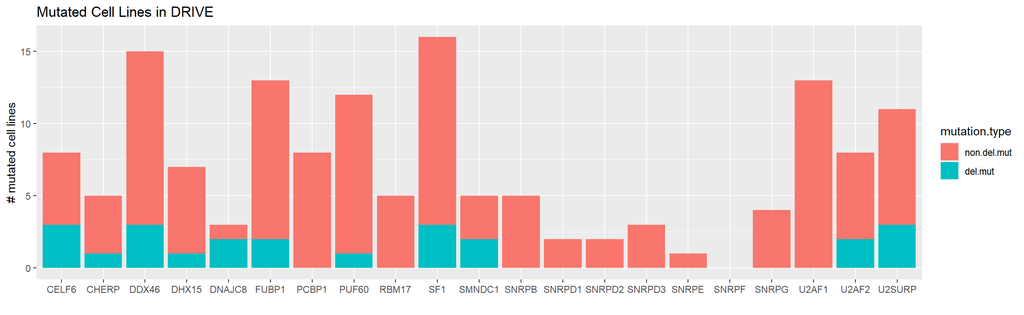

```r
mutation.stats.DRIVE.melt <- melt(mutation.stats.DRIVE,id="U2.genes")
colnames(mutation.stats.DRIVE.melt) <- c("gene","mutation.type","counts")

ggplot(mutation.stats.DRIVE.melt,aes(fill=mutation.type,x=gene,y=counts)) +
  geom_bar(stat="identity") +
  ylab("# mutated cell lines") + xlab("") +
  ggtitle("Mutated Cell Lines in DRIVE")
```

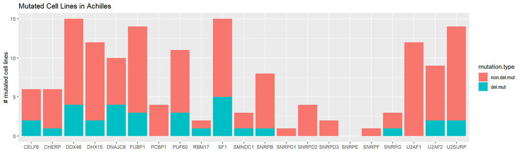

```r
mutation.stats.Achilles.melt <- melt(mutation.stats.Achilles,id="U2.genes")
colnames(mutation.stats.Achilles.melt) <- c("gene","mutation.type","counts")

ggplot(mutation.stats.Achilles.melt,aes(fill=mutation.type,x=gene,y=counts)) +
  geom_bar(stat="identity") +
  ylab("# mutated cell lines") + xlab("") +
  ggtitle("Mutated Cell Lines in Achilles")
```

## Classification Tables for U2 genes

Now we create a classification table in which each cell line is classified as deleterious if at least one U2 gene has a deleterious mutation.

```r
create.classification.table <- switch(classification.method,
                "del.vs.non.del" = create.classification.table.del.vs.non.del,
                "del.vs.non.mut" = create.classification.table.del.vs.non.mut,
                "mut.vs.non.mut" = create.classification.table.mut.vs.non.mut)

# create data structure
class.table.U2 <- create.classification.table(CCLE.mut, cancer.names,
                                              U2.genes[1], dep.scores.DRIVE,
                                              dep.scores.Achilles)
class.table.U2.DRIVE <- class.table.U2$DRIVE
class.table.U2.Achilles <- class.table.U2$Achilles

for (gene in U2.genes) {
  class.table <- create.classification.table(CCLE.mut, cancer.names,
                                             gene, dep.scores.DRIVE,
                                             dep.scores.Achilles)
  class.table.DRIVE <- class.table$DRIVE
  class.table.Achilles <- class.table$Achilles

  # merge with existing classifications
  class.table.DRIVE <- merge(class.table.U2.DRIVE,class.table.DRIVE,
                             by="CCLE_ID",all = TRUE)
  class.table.DRIVE[is.na(class.table.DRIVE)] <- FALSE
  class.table.DRIVE$isDeleterious <- ifelse(class.table.DRIVE$isDeleterious.x |
                                              class.table.DRIVE$isDeleterious.y,
                                            TRUE, FALSE)
  class.table.DRIVE$isDeleterious.x <- NULL
  class.table.DRIVE$isDeleterious.y <- NULL

  class.table.U2.DRIVE <- class.table.DRIVE

  # do the same with Achilles
  class.table.Achilles <- merge(class.table.U2.Achilles,class.table.Achilles,
                             by="CCLE_ID",all = TRUE)
  class.table.Achilles[is.na(class.table.Achilles)] <- FALSE
  class.table.Achilles$isDeleterious <- ifelse(
    class.table.Achilles$isDeleterious.x | class.table.Achilles$isDeleterious.y,
    TRUE, FALSE)
  class.table.Achilles$isDeleterious.x <- NULL
  class.table.Achilles$isDeleterious.y <- NULL

  class.table.U2.Achilles <- class.table.Achilles
}

head(class.table.U2.DRIVE)
```

```
##                                  CCLE_ID isDeleterious
## 1                     127399_SOFT_TISSUE         FALSE
## 2          1321N1_CENTRAL_NERVOUS_SYSTEM         FALSE
## 3                        2313287_STOMACH         FALSE
## 4 697_HAEMATOPOIETIC_AND_LYMPHOID_TISSUE         FALSE
## 5                            769P_KIDNEY         FALSE
## 6                            786O_KIDNEY         FALSE
```

```r
#rm(CCLE.mut,cancer.names)
```

## Classifications for U2 Genes

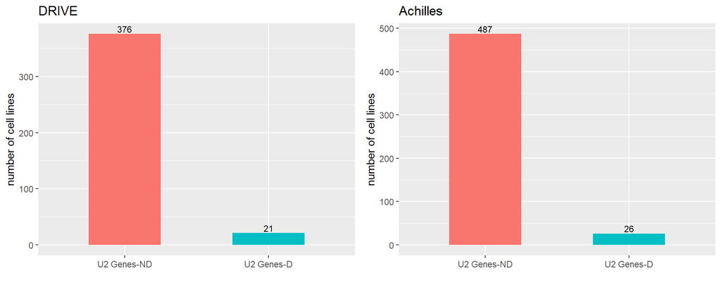

```r
barcharts.comb.genes <- create_barcharts_classifications(class.table.U2.DRIVE,
                                              class.table.U2.Achilles,
                                              "U2 Genes")
plot_grid(barcharts.comb.genes$DRIVE, barcharts.comb.genes$Achilles)
```

```r
rm(barcharts.comb.genes)
```

# Data Analysis U2 Genes

## Mean Differences

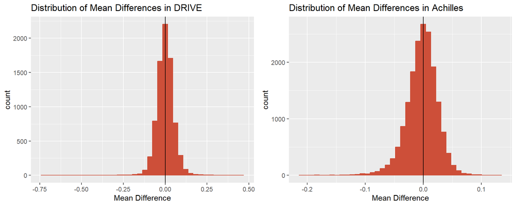

```r
test.results <- calc.mean.diffs.and.p.values(dep.scores.DRIVE,
                                           dep.scores.Achilles,
                                           class.table.U2.DRIVE,
                                           class.table.U2.Achilles)

plots <- plot.mean.diffs(test.results)
grid.arrange(plots$DRIVE,plots$Achilles,ncol=2)
```

```r
rm(class.table.U2.DRIVE,class.table.U2.Achilles,plots)
```

## Welch Test

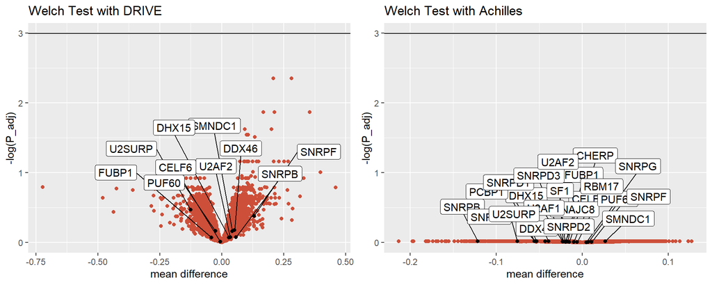

```r
plot.welch.DRIVE <- create_volcano_plot(test.results,"DRIVE",
                                        "welch",target.genes)

plot.welch.Achilles <- create_volcano_plot(test.results,"Achilles",
                                           "welch",target.genes)

grid.arrange(plot.welch.DRIVE,plot.welch.Achilles,ncol=2)
```

```r
rm(plot.welch.DRIVE,plot.welch.Achilles)
```

```r
significant.genes.table.DRIVE <- create.significant.genes.table(
  test.results,"DRIVE","welch")
significant.genes.table.Achilles <- create.significant.genes.table(
  test.results,"Achilles","welch")
significant.genes.table.DRIVE
```

```
## [1] gene    p_value p_adj   log
## <0 rows> (or 0-length row.names)
```

```r
significant.genes.table.Achilles
```

```
## [1] gene    p_value p_adj   log
## <0 rows> (or 0-length row.names)
```

```r
rm(significant.genes.table.DRIVE,significant.genes.table.Achilles)
```

## Wilcoxon Test

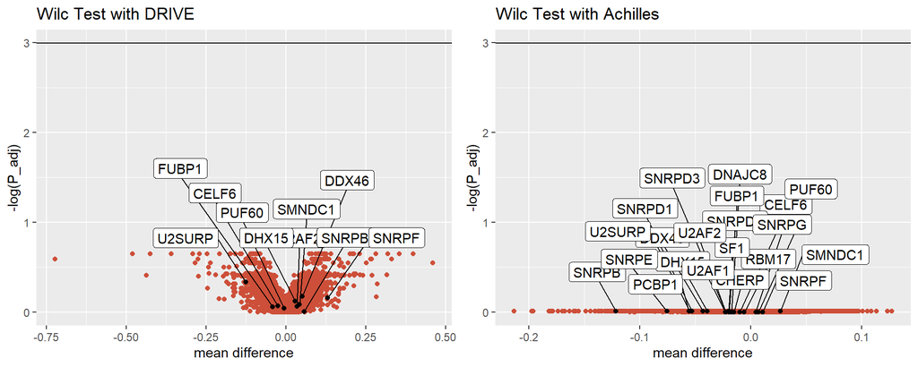

```r
plot.wilc.DRIVE <- create_volcano_plot(test.results,"DRIVE","wilc",
                                       target.genes, show_sign_line=T)

plot.wilc.Achilles <- create_volcano_plot(test.results,"Achilles",
                                                "wilc",target.genes)

grid.arrange(plot.wilc.DRIVE,plot.wilc.Achilles,ncol=2)
```

```r
rm(plot.wilc.DRIVE,plot.wilc.Achilles)
```

```r
significant.genes.table.DRIVE <- create.significant.genes.table(
  test.results,"DRIVE","wilc")
significant.genes.table.Achilles <- create.significant.genes.table(
  test.results,"Achilles","wilc")
significant.genes.table.DRIVE
```

```
## [1] gene    p_value p_adj   log
## <0 rows> (or 0-length row.names)
```

```r
significant.genes.table.Achilles
```

```
## [1] gene    p_value p_adj   log
## <0 rows> (or 0-length row.names)
```

```r
rm(significant.genes.table.DRIVE,significant.genes.table.Achilles)
```

## Bayes Test

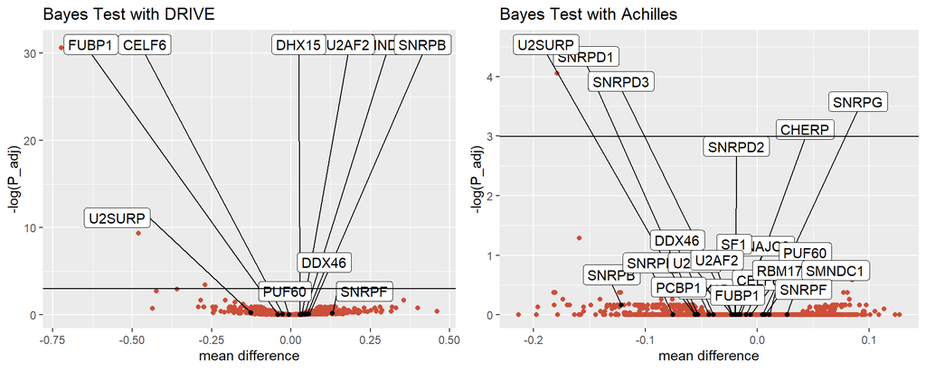

```r
plot.bayes.DRIVE <- create_volcano_plot(test.results,"DRIVE",
                                        "bayes",target.genes)

plot.bayes.Achilles <- create_volcano_plot(test.results,
                                           "Achilles","bayes",
                                           target.genes)

grid.arrange(plot.bayes.DRIVE,plot.bayes.Achilles,ncol=2)
```

```r
rm(plot.bayes.DRIVE,plot.bayes.Achilles)
```

```r
significant.genes.table.DRIVE <- create.significant.genes.table(
  test.results,"DRIVE","bayes")
significant.genes.table.Achilles <- create.significant.genes.table(
  test.results,"Achilles","bayes")
significant.genes.table.DRIVE
```

```
##         gene        p_adj       log
## 6474     WRN 5.045528e-14 30.617689
## 1738 RPL22L1 8.774087e-05  9.341123
## 5005   RNPC3 3.142455e-02  3.460166
```

```r
significant.genes.table.Achilles
```

```
##       gene      p_adj      log
## 15807 TPK1 0.01734106 4.054678
```

```r
rm(significant.genes.table.DRIVE,significant.genes.table.Achilles,
   test.results)
```